# Project Python Foundations: FoodHub Data Analysis

**Marks: 60**

### Context

The number of restaurants in New York is increasing day by day. Lots of students and busy professionals rely on those restaurants due to their hectic lifestyles. Online food delivery service is a great option for them. It provides them with good food from their favorite restaurants. A food aggregator company FoodHub offers access to multiple restaurants through a single smartphone app.

The app allows the restaurants to receive a direct online order from a customer. The app assigns a delivery person from the company to pick up the order after it is confirmed by the restaurant. The delivery person then uses the map to reach the restaurant and waits for the food package. Once the food package is handed over to the delivery person, he/she confirms the pick-up in the app and travels to the customer's location to deliver the food. The delivery person confirms the drop-off in the app after delivering the food package to the customer. The customer can rate the order in the app. The food aggregator earns money by collecting a fixed margin of the delivery order from the restaurants.

### Objective

The food aggregator company has stored the data of the different orders made by the registered customers in their online portal. They want to analyze the data to get a fair idea about the demand of different restaurants which will help them in enhancing their customer experience. Suppose you are hired as a Data Scientist in this company and the Data Science team has shared some of the key questions that need to be answered. Perform the data analysis to find answers to these questions that will help the company to improve the business.

### Data Description

The data contains the different data related to a food order. The detailed data dictionary is given below.

### Data Dictionary

- order_id: Unique ID of the order
- customer_id: ID of the customer who ordered the food
- restaurant_name: Name of the restaurant
- cuisine_type: Cuisine ordered by the customer
- cost: Cost of the order
- day_of_the_week: Indicates whether the order is placed on a weekday or weekend (The weekday is from Monday to Friday and the weekend is Saturday and Sunday)
- rating: Rating given by the customer out of 5
- food_preparation_time: Time (in minutes) taken by the restaurant to prepare the food. This is calculated by taking the difference between the timestamps of the restaurant's order confirmation and the delivery person's pick-up confirmation.
- delivery_time: Time (in minutes) taken by the delivery person to deliver the food package. This is calculated by taking the difference between the timestamps of the delivery person's pick-up confirmation and drop-off information

### Let us start by importing the required libraries

```python
import warnings
warnings.filterwarnings('ignore')
```

```python
# import libraries for data manipulation
import numpy as np
import pandas as pd

# import libraries for data visualization
import matplotlib.pyplot as plt
import seaborn as sns
sns.set(color_codes=True)
%matplotlib inline
```

### Understanding the structure of the data

```python
# read the data
data = pd.read_csv('foodhub_order.csv')
df = data.copy()
# returns the first 5 rows
df.head()
```

|  | order_id | customer_id | restaurant_name | cuisine_type | cost_of_the_order | day_of_the_week | rating | food_preparation_time | delivery_time |
| --- | --- | --- | --- | --- | --- | --- | --- | --- | --- |
| 0 | 1477147 | 337525 | Hangawi | Korean | 30.75 | Weekend | Not given | 25 | 20 |
| 1 | 1477685 | 358141 | Blue Ribbon Sushi Izakaya | Japanese | 12.08 | Weekend | Not given | 25 | 23 |
| 2 | 1477070 | 66393 | Cafe Habana | Mexican | 12.23 | Weekday | 5 | 23 | 28 |
| 3 | 1477334 | 106968 | Blue Ribbon Fried Chicken | American | 29.20 | Weekend | 3 | 25 | 15 |
| 4 | 1478249 | 76942 | Dirty Bird to Go | American | 11.59 | Weekday | 4 | 25 | 24 |

#### Observations:

The DataFrame has 9 columns as mentioned in the Data Dictionary. Data in each row corresponds to the order placed by a customer.

### **Question 1:** How many rows and columns are present in the data? [0.5 mark]

```python
#check the shape of the dataset
df.shape
```

```
(1898, 9)
```

#### Observations:

There are 1,898 rows and 9 columns present in the data

### **Question 2:** What are the datatypes of the different columns in the dataset? (The info() function can be used) [0.5 mark]

```python
# Use info() to print a concise summary of the DataFrame
df.info()
```

```
<class 'pandas.core.frame.DataFrame'>
RangeIndex: 1898 entries, 0 to 1897
Data columns (total 9 columns):
 #   Column                 Non-Null Count  Dtype
---  ------                 --------------  -----
 0   order_id               1898 non-null   int64
 1   customer_id            1898 non-null   int64
 2   restaurant_name        1898 non-null   object
 3   cuisine_type           1898 non-null   object
 4   cost_of_the_order      1898 non-null   float64
 5   day_of_the_week        1898 non-null   object
 6   rating                 1898 non-null   object
 7   food_preparation_time  1898 non-null   int64
 8   delivery_time          1898 non-null   int64
dtypes: float64(1), int64(4), object(4)
memory usage: 133.6+ KB
```

### **Question 3:** 'restaurant_name', 'cuisine_type', 'day_of_the_week' are object type attributes. Convert them to 'category' type. Does this result in reduced memory usage? (Check the info() function) [1 mark]

```python
# Converting "objects" to "category" reduces the data space required to store the dataframe
# write the code to convert 'restaurant_name', 'cuisine_type', 'day_of_the_week' into categorical data

for col in ['restaurant_name', 'cuisine_type', 'day_of_the_week', 'rating']:
    df[col] = df[col].astype('category')

# Use info() to print a concise summary of the DataFrame
df.info()
```

```
<class 'pandas.core.frame.DataFrame'>
RangeIndex: 1898 entries, 0 to 1897
Data columns (total 9 columns):
 #   Column                 Non-Null Count  Dtype
---  ------                 --------------  -----
 0   order_id               1898 non-null   int64
 1   customer_id            1898 non-null   int64
 2   restaurant_name        1898 non-null   category
 3   cuisine_type           1898 non-null   category
 4   cost_of_the_order      1898 non-null   float64
 5   day_of_the_week        1898 non-null   category
 6   rating                 1898 non-null   category
 7   food_preparation_time  1898 non-null   int64
 8   delivery_time          1898 non-null   int64
dtypes: category(4), float64(1), int64(4)
memory usage: 90.0 KB
```

#### Observations:

Yes, converting objects to categories reduces the memory usage. The memory usage reduced from 133.6+ KB to 90.0 KB.

```python
cat_col=['restaurant_name', 'cuisine_type', 'day_of_the_week', 'rating']
for column in cat_col:
        print(df[column].value_counts())
        print('-'*50)
```

```
Shake Shack                  219
The Meatball Shop            132
Blue Ribbon Sushi            119
Blue Ribbon Fried Chicken     96
Parm                          68
                            ...
Klong                          1
Kambi Ramen House              1
Il Bambino                     1
Hunan Manor                    1
Lamarca Pasta                  1
Name: restaurant_name, Length: 178, dtype: int64
--------------------------------------------------
American          584
Japanese          470
Italian           298
Chinese           215
Mexican            77
Indian             73
Middle Eastern     49
Mediterranean      46
Thai               19
French             18
Southern           17
Korean             13
Spanish            12
Vietnamese          7
Name: cuisine_type, dtype: int64
--------------------------------------------------
Weekend    1351
Weekday     547
Name: day_of_the_week, dtype: int64
--------------------------------------------------
Not given    736
5            588
4            386
3            188
Name: rating, dtype: int64
--------------------------------------------------
```

### **Question 4:** Check the statistical summary of the data. What is the minimum, average, and maximum time it takes for food to be prepared once an order is placed? [2 marks]

```python
#summary statistics of numerical data
df.describe()
```

|  | order_id | customer_id | cost_of_the_order | food_preparation_time | delivery_time |
| --- | --- | --- | --- | --- | --- |
| count | 1.898000e+03 | 1898.000000 | 1898.000000 | 1898.000000 | 1898.000000 |
| mean | 1.477496e+06 | 171168.478398 | 16.498851 | 27.371970 | 24.161749 |
| std | 5.480497e+02 | 113698.139743 | 7.483812 | 4.632481 | 4.972637 |
| min | 1.476547e+06 | 1311.000000 | 4.470000 | 20.000000 | 15.000000 |
| 25% | 1.477021e+06 | 77787.750000 | 12.080000 | 23.000000 | 20.000000 |
| 50% | 1.477496e+06 | 128600.000000 | 14.140000 | 27.000000 | 25.000000 |
| 75% | 1.477970e+06 | 270525.000000 | 22.297500 | 31.000000 | 28.000000 |
| max | 1.478444e+06 | 405334.000000 | 35.410000 | 35.000000 | 33.000000 |

#### Observations:

The minimum time it takes for food to be prepared once an order is placed is 20 minutes, the average time is 27.37 minutes, and the maximum amount of time it takes for food to be prepared once the order is placed is 35 minutes.

### **Question 5:** How many orders are not rated? [1 mark]

```python
df['rating'].value_counts()
```

```
Not given    736
5            588
4            386
3            188
Name: rating, dtype: int64
```

#### Observations:

736 orders are not rated.

### Exploratory Data Analysis (EDA)

### **Question 6:** Explore all the variables and provide observations on their distributions. (Generally, histograms, boxplots, countplots, etc. are used for univariate exploration.) [9 marks]

```python
def histogram_boxplot(df, feature, figsize=(12,7), kde=False, bins=None):
    """
    Boxplot and histogram combined

    df: dataframe
    feature: dataframe column
    kde: whether to show the density curve (default False)
    bins: number of bins for histogram (default None)
    """
    f2, (ax_box2, ax_hist2) = plt.subplots(
        nrows=2,
        sharex=True,
        figsize=figsize,
    )
    sns.boxplot(
        data=data, x=feature, ax=ax_box2, showmeans=True, color="violet"
    )
    sns.histplot(
        data=data, x=feature, kde=kde, ax=ax_hist2, bins=bins, palette="Winter"
    )   if bins else sns.histplot(
        data=data, x=feature, kde=kde, ax=ax_hist2
    )
    ax_hist2.axvline(
        df[feature].mean(), color="green", linestyle="--"
    )
    ax_hist2.axvline(
        df[feature].median(), color="black", linestyle="--"
    )
```

### Cost of the Order

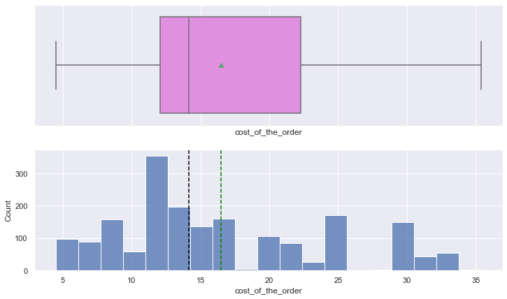

```python
histogram_boxplot(df, 'cost_of_the_order')
```

#### Observations

- The distribution of cost of the order is right-skewed
- The median cost of order is around 14
- The mean cost of order is around 17

### Food Preparation Time

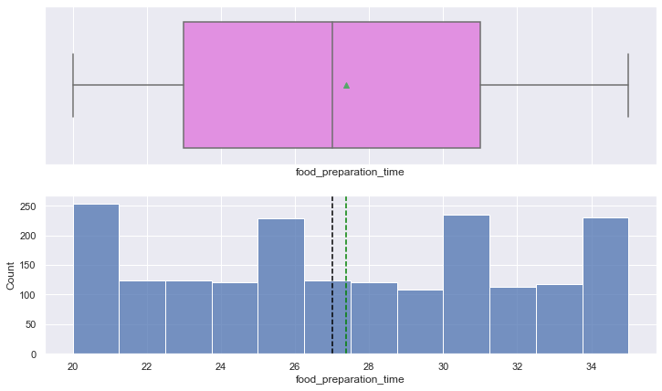

```python
histogram_boxplot(df, 'food_preparation_time')
```

### Delivery Time

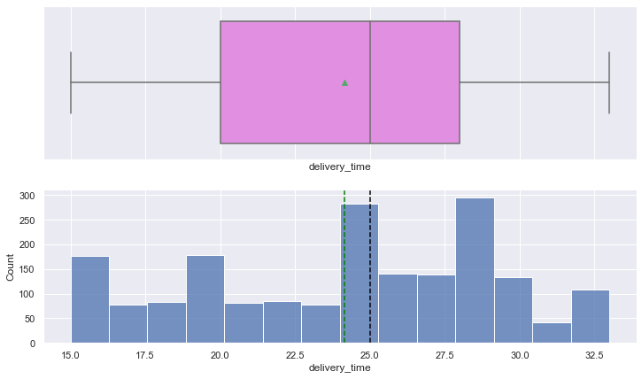

```python
histogram_boxplot(df, 'delivery_time')
```

#### Observations

```python
def labeled_barplot(df, feature, perc=False, n=None):
    total = len(df[feature])
    count = df[feature].nunique()
    if n is None:
        plt.figure(figsize=(count + 1,5))
    else:
        plt.figure(figsize=(n + 1, 5))
    plt.xticks(rotation=90, fontsize=15)
    ax = sns.countplot(
        data=data,
        x=feature,
        palette="Paired",
        order=df[feature].value_counts().index[:n].sort_values(),
    )

    for p in ax.patches:
        if perc == True:
            label = "{:.1f}%".format(
                100 * p.get_height() / total
            )
    else:
        label = p.get_height()

        x = p.get_x() + p.get_width() / 2
        y = p.get_height()

    ax.annotate(
        label,
        (x,y),
        ha="center",
        va="center",
        size=12,
        xytext=(0,5),
        textcoords="offset points",
    )
plt.show()
```

### Name of Restuaruant

[figure not shown]

```python
plt.figure(figsize=(10,7))
labeled_barplot(df, 'restaurant_name', perc=True)
```

#### Observations

- The most popular restaurants are Shake Shack, The Meatball Shop, Blue Ribbon Sushi, Blue Ribbon Fried Chicken, and Parm

### Type of Cuisine

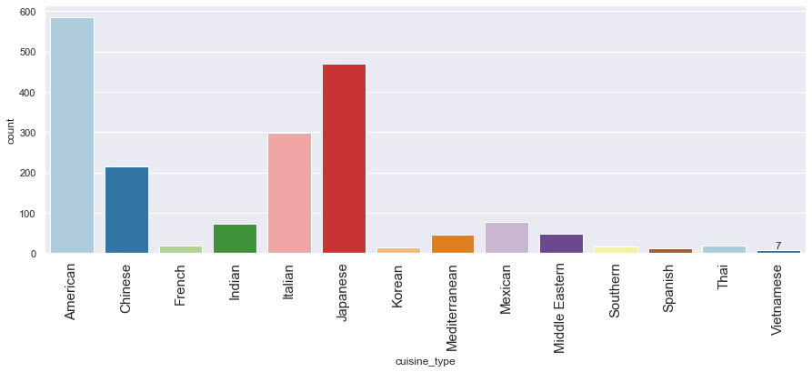

```python
plt.figure(figsize=(10,7))
labeled_barplot(df, 'cuisine_type', perc=True)
```

#### Observations

- The most popular cuisines ordered are American, Japanese, Italian, and Chinese food

### Day of the Week

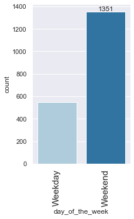

```python
plt.figure(figsize=(10,7))
labeled_barplot(df, 'day_of_the_week', perc=True)
```

### Rating

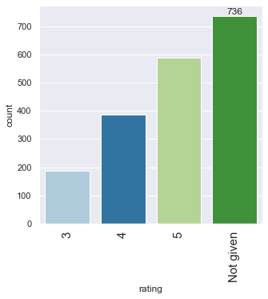

```python
plt.figure(figsize=(10,7))
labeled_barplot(df, 'rating', perc=True)
```

### **Question 7**: Which are the top 5 restaurants in terms of the number of orders received? [1 mark]

```python
df.groupby('restaurant_name').size().sort_values(ascending=False)
```

```
restaurant_name
Shake Shack                  219
The Meatball Shop            132
Blue Ribbon Sushi            119
Blue Ribbon Fried Chicken     96
Parm                          68
                            ...
Klong                          1
Kambi Ramen House              1
Il Bambino                     1
Hunan Manor                    1
Lamarca Pasta                  1
Length: 178, dtype: int64
```

#### Observations:

The top five restaurants in terms of orders recieved are Shake Shack, The Meatball Shop, Blue Ribbon Sushi, Blue Ribbon Fried Chicken, and Parm.

```python
#alternate method
df['restaurant_name'].value_counts()[:5]
```

```
Shake Shack                  219
The Meatball Shop            132
Blue Ribbon Sushi            119
Blue Ribbon Fried Chicken     96
Parm                          68
Name: restaurant_name, dtype: int64
```

### **Question 8**: Which is the most popular cuisine on weekends? [1 mark]

```python
df[df["day_of_the_week"]=="Weekend"].describe(include="all")
```

|  | order_id | customer_id | restaurant_name | cuisine_type | cost_of_the_order | day_of_the_week | rating | food_preparation_time | delivery_time |
| --- | --- | --- | --- | --- | --- | --- | --- | --- | --- |
| count | 1.351000e+03 | 1351.000000 | 1351 | 1351 | 1351.000000 | 1351 | 1351 | 1351.000000 | 1351.000000 |
| unique | NaN | NaN | 159 | 14 | NaN | 1 | 4 | NaN | NaN |
| top | NaN | NaN | Shake Shack | American | NaN | Weekend | Not given | NaN | NaN |
| freq | NaN | NaN | 145 | 415 | NaN | 1351 | 529 | NaN | NaN |
| mean | 1.477500e+06 | 170422.561066 | NaN | NaN | 16.574833 | NaN | NaN | 27.436714 | 22.470022 |
| std | 5.541681e+02 | 113403.749068 | NaN | NaN | 7.486979 | NaN | NaN | 4.601476 | 4.628938 |
| min | 1.476547e+06 | 1311.000000 | NaN | NaN | 4.470000 | NaN | NaN | 20.000000 | 15.000000 |
| 25% | 1.477016e+06 | 77665.000000 | NaN | NaN | 12.080000 | NaN | NaN | 23.000000 | 18.500000 |
| 50% | 1.477505e+06 | 127934.000000 | NaN | NaN | 14.410000 | NaN | NaN | 27.000000 | 22.000000 |
| 75% | 1.477980e+06 | 268958.000000 | NaN | NaN | 22.285000 | NaN | NaN | 31.000000 | 27.000000 |
| max | 1.478444e+06 | 405334.000000 | NaN | NaN | 33.370000 | NaN | NaN | 35.000000 | 30.000000 |

#### Observations:

American is the most popular cuisine on weekends.

```python
#alternate method
df_weekend = df[df['day_of_the_week']== 'Weekend']
df_weekend['cuisine_type'].value_counts()
```

```
American          415
Japanese          335
Italian           207
Chinese           163
Mexican            53
Indian             49
Mediterranean      32
Middle Eastern     32
Thai               15
French             13
Korean             11
Southern           11
Spanish            11
Vietnamese          4
Name: cuisine_type, dtype: int64
```

### **Question 9**: What percentage of the orders cost more than 20 dollars? [2 marks]

```python
more_than_20 = df[df['cost_of_the_order']>20]
```

```python
print (more_than_20)
```

```
      order_id  customer_id                        restaurant_name  \
0      1477147       337525                                Hangawi
3      1477334       106968              Blue Ribbon Fried Chicken
5      1477224       147468                       Tamarind TriBeCa
12     1476966       129969              Blue Ribbon Fried Chicken
17     1477373       139885              Blue Ribbon Sushi Izakaya
...        ...          ...                                    ...
1884   1477437       304993                            Shake Shack
1885   1477550        97324                            Shake Shack
1892   1477473        97838                            Han Dynasty
1893   1476701       292602  Chipotle Mexican Grill $1.99 Delivery
1895   1477819        35309                      Blue Ribbon Sushi

     cuisine_type  cost_of_the_order day_of_the_week     rating  \
0          Korean              30.75         Weekend  Not given
```

[output cut: 25 more lines]

```python
( 555 / 1898 ) * 100
```

```
29.24130663856691
```

#### Observations:

29.24% of orders cost more than $20

```python
#alternate method
#get the orders that cost above $20
df_greater_than_20 = df[df['cost_of_the_order']>20]

#calculate the number of total prders where the cost is above 20 dollars

print('The number of total orders that cost 20 dollars is:', df_greater_than_20.shape[0])

#calculate percentage of such orders in the dataset
percentage = (df_greater_than_20.shape[0] / df.shape[0]) * 100

print("Percentage of orders above 20 dollars:", round(percentage, 2), '%')
```

```
The number of total orders that cost 20 dollars is: 555
Percentage of orders above 20 dollars: 29.24 %
```

### **Question 10**: What is the mean order delivery time? [1 mark]

```python
df.describe()
```

|  | order_id | customer_id | cost_of_the_order | food_preparation_time | delivery_time |
| --- | --- | --- | --- | --- | --- |
| count | 1.898000e+03 | 1898.000000 | 1898.000000 | 1898.000000 | 1898.000000 |
| mean | 1.477496e+06 | 171168.478398 | 16.498851 | 27.371970 | 24.161749 |
| std | 5.480497e+02 | 113698.139743 | 7.483812 | 4.632481 | 4.972637 |
| min | 1.476547e+06 | 1311.000000 | 4.470000 | 20.000000 | 15.000000 |
| 25% | 1.477021e+06 | 77787.750000 | 12.080000 | 23.000000 | 20.000000 |
| 50% | 1.477496e+06 | 128600.000000 | 14.140000 | 27.000000 | 25.000000 |
| 75% | 1.477970e+06 | 270525.000000 | 22.297500 | 31.000000 | 28.000000 |
| max | 1.478444e+06 | 405334.000000 | 35.410000 | 35.000000 | 33.000000 |

#### Observations:

The mean order delivery time is about 24 minutes.

```python
#alternate method
print('The mean delivery time for this dataset is', round(df['delivery_time'].mean(), 2), 'minutes')
```

```
The mean delivery time for this dataset is 24.16 minutes
```

### **Question 11:** The company has decided to give 20% discount vouchers to the top 5 most frequent customers. Find the IDs of these customers and the number of orders they placed. [1 mark]

```python
df['customer_id'].value_counts()
```

```
52832     13
47440     10
83287      9
250494     8
65009      7
          ..
66393      1
142170     1
332635     1
147519     1
385023     1
Name: customer_id, Length: 1200, dtype: int64
```

#### Observations:

Customer ID 52832 is number one with 13 orders, 47440 is number two with 10 orders, 83287 is number three with 9 orders, 250494 is number four with 8 orders, and 65009 us number five with 7 orders.

### **Question 12**: Perform a multivariate analysis to explore relationships between the important variables in the dataset. (It is a good idea to explore relations between numerical variables as well as relations between numerical and categorical variables) [10 marks]

#### Correlation among variables

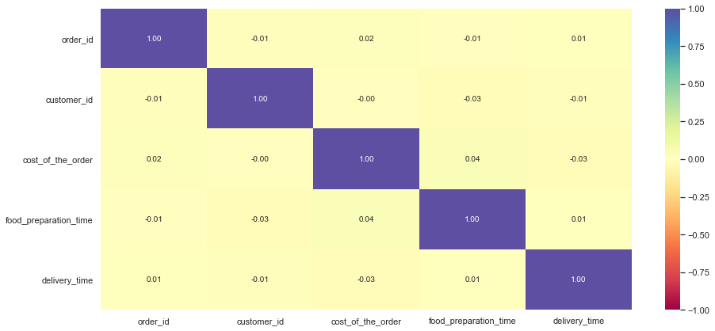

```python
num_var = ['order_id', 'customer_id', 'restaurant_name', 'cuisine_type', 'cost_of_the_order', 'day_of_the_week', 'rating', 'food_preparation_time', 'delivery_time']
corr = df[num_var].corr()

plt.figure(figsize=(15,7))
sns.heatmap(corr, annot=True, vmin=-1, vmax=1, fmt=".2f", cmap="Spectral", xticklabels=corr.columns, yticklabels=corr.columns)
plt.show()
```

#### Observations

- There is no correlation between cost of the order, delivery time, and food preparation time

#### Cuisine vs Cost of the order

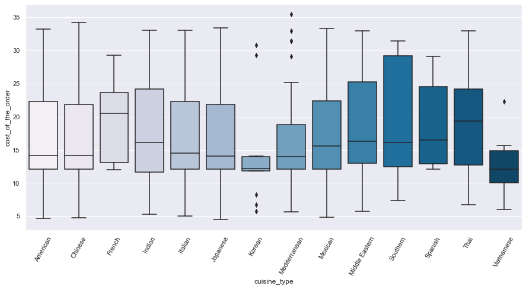

```python
# Relationship between cost of the order and cuisine type
plt.figure(figsize=(15,7))
sns.boxplot(x = "cuisine_type", y = "cost_of_the_order", data = df, palette = 'PuBu')
plt.xticks(rotation = 60)
plt.show()
```

#### Observations:

- Vietnamese and Korean cuisines cost less compared to other cuisines.
- The boxplots for Italian, American, Chinese, Japanese cuisines are quite similar. This indicates that the quartile costs for these cuisines are quite similar.
- Outliers are present for the cost of Korean, Mediterranean and Vietnamese cuisines.
- French and Spanish cuisines are costlier compared to other cuisines.

#### Cuisine vs Food Preparation time

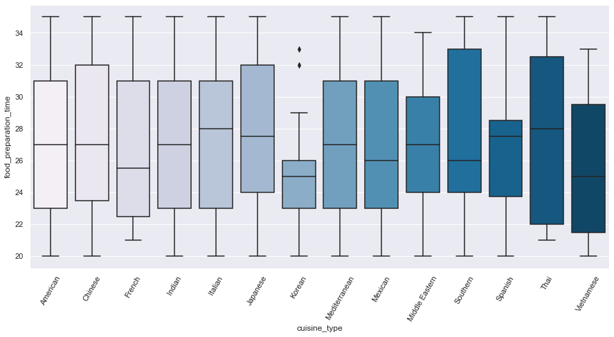

```python
# Relationship between food preparation time and cuisine type
plt.figure(figsize=(15,7))
sns.boxplot(x = "cuisine_type", y = "food_preparation_time", data = df, palette = 'PuBu')
plt.xticks(rotation = 60)
plt.show()
```

#### Observations:

- Food preparation time is very consistent for most of the cuisines.
- The median food preparation time lies between 24 and 30 minutes for all the cuisines.
- Outliers are present for the food preparation time of Korean cuisine.
- Korean cuisine takes less time compared to the other cuisines.

#### Day of the Week vs Delivery time

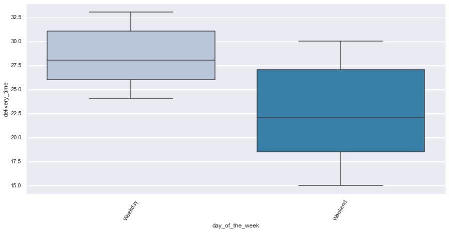

```python
# Relationship between day of the week and delivery time
plt.figure(figsize=(15,7))
sns.boxplot(x = "day_of_the_week", y = "delivery_time", data = df, palette = 'PuBu')
plt.xticks(rotation = 60)
plt.show()
```

#### Observations:

- The delivery time for all the orders over the weekends is less compared to weekdays. This could be due to the dip in traffic over the weekends.

#### Rating vs Delivery time

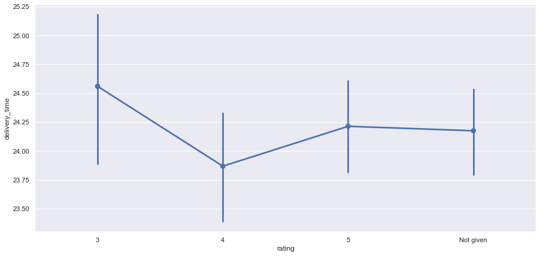

```python
# Relationship between rating and delivery time
plt.figure(figsize=(15, 7))
sns.pointplot(x = 'rating', y = 'delivery_time', data = df)
plt.show()
```

#### Observations:

- It is possible that delivery time plays a role in the low-rating of the orders.

#### Rating vs Food preparation time

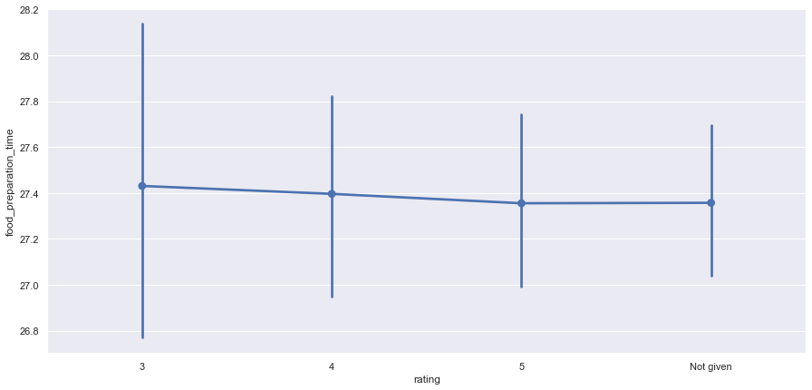

```python
# Relationship between rating and food preparation time
plt.figure(figsize=(15, 7))
sns.pointplot(x = 'rating', y = 'food_preparation_time', data = df)
plt.show()
```

#### Observations:

- It seems that food preparation time does not play a role in the low-rating of the orders.

#### Rating vs Cost of the order

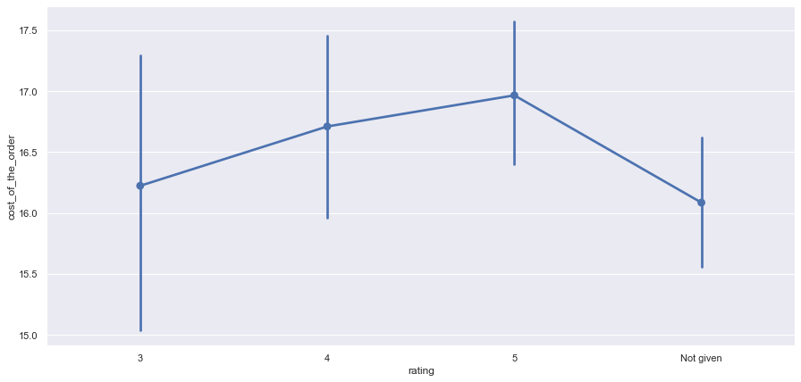

```python
# Relationship between rating and cost of the order
plt.figure(figsize=(15, 7))
sns.pointplot(x = 'rating', y = 'cost_of_the_order', data = df)
plt.show()
```

#### Observations

- It seems that high-cost orders have been rated well and low-cost orders have not been rated.

### **Question 13:** The company wants to provide a promotional offer in the advertisement of the restaurants. The condition to get the offer is that the restaurants must have a rating count of more than 50 and the average rating should be greater than 4. Find the restaurants fulfilling the criteria to get the promotional offer. [3 marks]

```python
df_rating =df[df['rating'] != "Not given"].copy()
df_rating['rating'].astype(str).astype(int)
```

```
2       5
3       3
4       4
5       3
7       3
       ..
1889    3
1890    5
1893    5
1894    5
1896    5
Name: rating, Length: 1162, dtype: int64
```

```python
df_rating_count = df_rating.groupby(['restaurant_name'])['rating'].count().sort_values(ascending = False).reset_index()
df_rating_count.head()
```

|  | restaurant_name | rating |
| --- | --- | --- |
| 0 | Shake Shack | 133 |
| 1 | The Meatball Shop | 84 |
| 2 | Blue Ribbon Sushi | 73 |
| 3 | Blue Ribbon Fried Chicken | 64 |
| 4 | RedFarm Broadway | 41 |

```python
df_rests= df_rating_count[df_rating_count['rating'] > 50]['restaurant_name']
df_rests.head()
```

```
0                  Shake Shack
1            The Meatball Shop
2            Blue Ribbon Sushi
3    Blue Ribbon Fried Chicken
Name: restaurant_name, dtype: category
Categories (178, object): [''wichcraft', '12 Chairs', '5 Napkin Burger', '67 Burger', ..., 'brgr', 'da Umberto', 'ilili Restaurant', 'indikitch']
```

```python
df[df["restaurant_name"]=="Shake Shack"].describe(include="all")
```

|  | order_id | customer_id | restaurant_name | cuisine_type | cost_of_the_order | day_of_the_week | rating | food_preparation_time | delivery_time |
| --- | --- | --- | --- | --- | --- | --- | --- | --- | --- |
| count | 2.190000e+02 | 219.000000 | 219 | 219 | 219.000000 | 219 | 219 | 219.000000 | 219.000000 |
| unique | NaN | NaN | 1 | 1 | NaN | 2 | 4 | NaN | NaN |
| top | NaN | NaN | Shake Shack | American | NaN | Weekend | Not given | NaN | NaN |
| freq | NaN | NaN | 219 | 219 | NaN | 145 | 86 | NaN | NaN |
| mean | 1.477527e+06 | 190994.593607 | NaN | NaN | 16.344886 | NaN | NaN | 27.945205 | 24.662100 |
| std | 5.314427e+02 | 116395.067654 | NaN | NaN | 7.305910 | NaN | NaN | 4.744549 | 4.795351 |
| min | 1.476554e+06 | 14869.000000 | NaN | NaN | 4.750000 | NaN | NaN | 20.000000 | 15.000000 |
| 25% | 1.477091e+06 | 89594.500000 | NaN | NaN | 12.105000 | NaN | NaN | 24.000000 | 21.000000 |
| 50% | 1.477542e+06 | 146588.000000 | NaN | NaN | 15.280000 | NaN | NaN | 28.000000 | 25.000000 |
| 75% | 1.478007e+06 | 301796.500000 | NaN | NaN | 22.095000 | NaN | NaN | 32.000000 | 28.000000 |
| max | 1.478444e+06 | 400390.000000 | NaN | NaN | 33.030000 | NaN | NaN | 35.000000 | 33.000000 |

```python
df[df["restaurant_name"]=="The Meatball Shop"].describe(include="all")
```

|  | order_id | customer_id | restaurant_name | cuisine_type | cost_of_the_order | day_of_the_week | rating | food_preparation_time | delivery_time |
| --- | --- | --- | --- | --- | --- | --- | --- | --- | --- |
| count | 1.320000e+02 | 132.000000 | 132 | 132 | 132.000000 | 132 | 132 | 132.000000 | 132.000000 |
| unique | NaN | NaN | 1 | 2 | NaN | 2 | 4 | NaN | NaN |
| top | NaN | NaN | The Meatball Shop | Italian | NaN | Weekend | 5 | NaN | NaN |
| freq | NaN | NaN | 132 | 112 | NaN | 95 | 53 | NaN | NaN |
| mean | 1.477495e+06 | 156440.015152 | NaN | NaN | 16.251591 | NaN | NaN | 27.181818 | 24.242424 |
| std | 5.574793e+02 | 110241.847420 | NaN | NaN | 7.505044 | NaN | NaN | 4.596411 | 5.016189 |
| min | 1.476577e+06 | 5693.000000 | NaN | NaN | 5.050000 | NaN | NaN | 20.000000 | 15.000000 |
| 25% | 1.477036e+06 | 79081.250000 | NaN | NaN | 11.982500 | NaN | NaN | 23.000000 | 20.000000 |
| 50% | 1.477404e+06 | 110992.500000 | NaN | NaN | 14.070000 | NaN | NaN | 28.000000 | 25.000000 |
| 75% | 1.477971e+06 | 232359.000000 | NaN | NaN | 21.462500 | NaN | NaN | 31.000000 | 28.000000 |
| max | 1.478423e+06 | 399584.000000 | NaN | NaN | 33.030000 | NaN | NaN | 35.000000 | 33.000000 |

```python
df[df["restaurant_name"]=="Blue Ribbon Sushi"].describe(include="all")
```

|  | order_id | customer_id | restaurant_name | cuisine_type | cost_of_the_order | day_of_the_week | rating | food_preparation_time | delivery_time |
| --- | --- | --- | --- | --- | --- | --- | --- | --- | --- |
| count | 1.190000e+02 | 119.000000 | 119 | 119 | 119.000000 | 119 | 119 | 119.000000 | 119.000000 |
| unique | NaN | NaN | 1 | 1 | NaN | 2 | 4 | NaN | NaN |
| top | NaN | NaN | Blue Ribbon Sushi | Japanese | NaN | Weekend | Not given | NaN | NaN |
| freq | NaN | NaN | 119 | 119 | NaN | 85 | 46 | NaN | NaN |
| mean | 1.477424e+06 | 163474.042017 | NaN | NaN | 15.999580 | NaN | NaN | 27.924370 | 23.941176 |
| std | 5.277364e+02 | 114653.591257 | NaN | NaN | 6.972963 | NaN | NaN | 4.758863 | 5.253399 |
| min | 1.476548e+06 | 35309.000000 | NaN | NaN | 5.820000 | NaN | NaN | 20.000000 | 15.000000 |
| 25% | 1.476940e+06 | 74344.000000 | NaN | NaN | 12.080000 | NaN | NaN | 24.000000 | 18.500000 |
| 50% | 1.477450e+06 | 123977.000000 | NaN | NaN | 14.020000 | NaN | NaN | 28.000000 | 25.000000 |
| 75% | 1.477842e+06 | 213736.500000 | NaN | NaN | 19.450000 | NaN | NaN | 32.000000 | 28.000000 |
| max | 1.478394e+06 | 399729.000000 | NaN | NaN | 33.370000 | NaN | NaN | 35.000000 | 33.000000 |

```python
df[df["restaurant_name"]=="Blue Ribbon Fried Chicken"].describe(include="all")
```

|  | order_id | customer_id | restaurant_name | cuisine_type | cost_of_the_order | day_of_the_week | rating | food_preparation_time | delivery_time |
| --- | --- | --- | --- | --- | --- | --- | --- | --- | --- |
| count | 9.600000e+01 | 96.000000 | 96 | 96 | 96.000000 | 96 | 96 | 96.000000 | 96.000000 |
| unique | NaN | NaN | 1 | 1 | NaN | 2 | 4 | NaN | NaN |
| top | NaN | NaN | Blue Ribbon Fried Chicken | American | NaN | Weekend | 5 | NaN | NaN |
| freq | NaN | NaN | 96 | 96 | NaN | 74 | 32 | NaN | NaN |
| mean | 1.477504e+06 | 184072.927083 | NaN | NaN | 17.315521 | NaN | NaN | 27.197917 | 24.145833 |
| std | 5.597241e+02 | 118857.921412 | NaN | NaN | 7.841893 | NaN | NaN | 4.740908 | 4.847092 |
| min | 1.476572e+06 | 41638.000000 | NaN | NaN | 5.730000 | NaN | NaN | 20.000000 | 15.000000 |
| 25% | 1.476994e+06 | 73513.250000 | NaN | NaN | 12.130000 | NaN | NaN | 23.000000 | 21.000000 |
| 50% | 1.477556e+06 | 135473.500000 | NaN | NaN | 14.335000 | NaN | NaN | 27.000000 | 25.000000 |
| 75% | 1.477972e+06 | 297861.750000 | NaN | NaN | 24.250000 | NaN | NaN | 31.000000 | 28.000000 |
| max | 1.478417e+06 | 399172.000000 | NaN | NaN | 33.180000 | NaN | NaN | 35.000000 | 33.000000 |

```python
more_than_20 = df[df['cost_of_the_order']>20]
more_than_5 = df[df['cost_of_the_order']>5]
```

### **Question 14:** The company charges the restaurant 25% on the orders having cost greater than 20 dollars and 15% on the orders having cost greater than 5 dollars. Find the net revenue generated by the company across all orders. [3 marks]

```python
print(more_than_20)
```

```
      order_id  customer_id                        restaurant_name  \
0      1477147       337525                                Hangawi
3      1477334       106968              Blue Ribbon Fried Chicken
5      1477224       147468                       Tamarind TriBeCa
12     1476966       129969              Blue Ribbon Fried Chicken
17     1477373       139885              Blue Ribbon Sushi Izakaya
...        ...          ...                                    ...
1884   1477437       304993                            Shake Shack
1885   1477550        97324                            Shake Shack
1892   1477473        97838                            Han Dynasty
1893   1476701       292602  Chipotle Mexican Grill $1.99 Delivery
1895   1477819        35309                      Blue Ribbon Sushi

     cuisine_type  cost_of_the_order day_of_the_week     rating  \
0          Korean              30.75         Weekend  Not given
```

[output cut: 25 more lines]

```python
print(more_than_5)
```

```
      order_id  customer_id                        restaurant_name  \
0      1477147       337525                                Hangawi
1      1477685       358141              Blue Ribbon Sushi Izakaya
2      1477070        66393                            Cafe Habana
3      1477334       106968              Blue Ribbon Fried Chicken
4      1478249        76942                       Dirty Bird to Go
...        ...          ...                                    ...
1893   1476701       292602  Chipotle Mexican Grill $1.99 Delivery
1894   1477421       397537                              The Smile
1895   1477819        35309                      Blue Ribbon Sushi
1896   1477513        64151                      Jack's Wife Freda
1897   1478056       120353                      Blue Ribbon Sushi

       cuisine_type  cost_of_the_order day_of_the_week     rating  \
0            Korean              30.75         Weekend  Not given
```

[output cut: 25 more lines]

#### Observations:

- 555 orders cost more than 20 dollars
- 1889 orders cost more than 5 dollars

```python
#function to determine the net revenue
def compute_rev(x):
    if x > 20:
        return x*0.25
    elif x > 5:
        return x*0.15
    else:
        return x*0

df['Revenue'] = df['cost_of_the_order'].apply(compute_rev)
df.head()
```

|  | order_id | customer_id | restaurant_name | cuisine_type | cost_of_the_order | day_of_the_week | rating | food_preparation_time | delivery_time | Revenue |
| --- | --- | --- | --- | --- | --- | --- | --- | --- | --- | --- |
| 0 | 1477147 | 337525 | Hangawi | Korean | 30.75 | Weekend | Not given | 25 | 20 | 7.6875 |
| 1 | 1477685 | 358141 | Blue Ribbon Sushi Izakaya | Japanese | 12.08 | Weekend | Not given | 25 | 23 | 1.8120 |
| 2 | 1477070 | 66393 | Cafe Habana | Mexican | 12.23 | Weekday | 5 | 23 | 28 | 1.8345 |
| 3 | 1477334 | 106968 | Blue Ribbon Fried Chicken | American | 29.20 | Weekend | 3 | 25 | 15 | 7.3000 |
| 4 | 1478249 | 76942 | Dirty Bird to Go | American | 11.59 | Weekday | 4 | 25 | 24 | 1.7385 |

```python
# get the total revenue and print it
total_rev = df['Revenue'].sum()
print('The net revenue is around', round(total_rev, 2), 'dollars')
```

```
The net revenue is around 6166.3 dollars
```

#### Observations:

- The net revenue generated on all the orders given in the dataset is around 6166.3 dollars.

### **Question 15:** The company wants to analyze the total time required to deliver the food. What percentage of orders take more than 60 minutes to get delivered from the time the order is placed? (The food has to be prepared and then delivered.) [2 marks]

```python
df ['food_preparation_time'].astype(int)
df['delivery_time'].astype(int)
df['total_time'] = df['food_preparation_time'] + df['delivery_time']
more_than_60 = df[df['total_time']>60]
print(more_than_60)
```

```
      order_id  customer_id             restaurant_name    cuisine_type  \
7      1477859        89574                   Barbounia   Mediterranean
10     1477895       143926  Big Wong Restaurant _¤¾Ñ¼         Chinese
19     1477354        67487           Blue Ribbon Sushi        Japanese
24     1476714       363783                Cafe Mogador  Middle Eastern
54     1477760       130507           Jack's Wife Freda   Mediterranean
...        ...          ...                         ...             ...
1869   1476923        50199                 J. G. Melon        American
1873   1478148       261371                 Shake Shack        American
1875   1478039       292343                  Amy Ruth's        Southern
1880   1477466       222734                 Shake Shack        American
1889   1478190        94152            RedFarm Broadway         Chinese

      cost_of_the_order day_of_the_week     rating  food_preparation_time  \
7                  5.97         Weekday          3                     33
```

[output cut: 25 more lines]

```python
200 / 1898 * 100
```

```
10.537407797681771
```

#### Observations:

About 10.54% of orders take more than 60 minutes to get delivered from the time the order is placed.

```python
#alternate method
# add a new column to the dataframe df to store the total delivery time
df['total_time'] = df['food_preparation_time'] + df['delivery_time']

# find the percentage of orders that have more than 60 minutes of total delivery time
print ('The percentage of orders that have more than 60 minutes of total delivery time is',
       round(df[df['total_time'] > 60].shape[0] / df.shape[0] * 100, 2),'%')
```

```
The percentage of orders that have more than 60 minutes of total delivery time is 10.54 %
```

### **Question 16:** The company wants to analyze the delivery time of the orders on weekdays and weekends. How does the mean delivery time vary during weekdays and weekends? [2 marks]

```python
df[df["day_of_the_week"]=="Weekend"].describe(include="all")
```

|  | order_id | customer_id | restaurant_name | cuisine_type | cost_of_the_order | day_of_the_week | rating | food_preparation_time | delivery_time | Revenue | total_time |
| --- | --- | --- | --- | --- | --- | --- | --- | --- | --- | --- | --- |
| count | 1.351000e+03 | 1351.000000 | 1351 | 1351 | 1351.000000 | 1351 | 1351 | 1351.000000 | 1351.000000 | 1351.000000 | 1351.000000 |
| unique | NaN | NaN | 159 | 14 | NaN | 1 | 4 | NaN | NaN | NaN | NaN |
| top | NaN | NaN | Shake Shack | American | NaN | Weekend | Not given | NaN | NaN | NaN | NaN |
| freq | NaN | NaN | 145 | 415 | NaN | 1351 | 529 | NaN | NaN | NaN | NaN |
| mean | 1.477500e+06 | 170422.561066 | NaN | NaN | 16.574833 | NaN | NaN | 27.436714 | 22.470022 | 3.265706 | 49.906736 |
| std | 5.541681e+02 | 113403.749068 | NaN | NaN | 7.486979 | NaN | NaN | 4.601476 | 4.628938 | 2.303151 | 6.624883 |
| min | 1.476547e+06 | 1311.000000 | NaN | NaN | 4.470000 | NaN | NaN | 20.000000 | 15.000000 | 0.000000 | 35.000000 |
| 25% | 1.477016e+06 | 77665.000000 | NaN | NaN | 12.080000 | NaN | NaN | 23.000000 | 18.500000 | 1.812000 | 45.000000 |
| 50% | 1.477505e+06 | 127934.000000 | NaN | NaN | 14.410000 | NaN | NaN | 27.000000 | 22.000000 | 2.161500 | 50.000000 |
| 75% | 1.477980e+06 | 268958.000000 | NaN | NaN | 22.285000 | NaN | NaN | 31.000000 | 27.000000 | 5.571250 | 55.000000 |
| max | 1.478444e+06 | 405334.000000 | NaN | NaN | 33.370000 | NaN | NaN | 35.000000 | 30.000000 | 8.342500 | 65.000000 |

```python
df[df["day_of_the_week"]=="Weekday"].describe(include="all")
```

|  | order_id | customer_id | restaurant_name | cuisine_type | cost_of_the_order | day_of_the_week | rating | food_preparation_time | delivery_time | Revenue | total_time |
| --- | --- | --- | --- | --- | --- | --- | --- | --- | --- | --- | --- |
| count | 5.470000e+02 | 547.000000 | 547 | 547 | 547.000000 | 547 | 547 | 547.000000 | 547.000000 | 547.000000 | 547.000000 |
| unique | NaN | NaN | 121 | 14 | NaN | 1 | 4 | NaN | NaN | NaN | NaN |
| top | NaN | NaN | Shake Shack | American | NaN | Weekday | Not given | NaN | NaN | NaN | NaN |
| freq | NaN | NaN | 74 | 169 | NaN | 547 | 207 | NaN | NaN | NaN | NaN |
| mean | 1.477483e+06 | 173010.771481 | NaN | NaN | 16.311188 | NaN | NaN | 27.212066 | 28.340037 | 3.207193 | 55.552102 |
| std | 5.329454e+02 | 114505.333032 | NaN | NaN | 7.479521 | NaN | NaN | 4.708616 | 2.891428 | 2.278398 | 5.567972 |
| min | 1.476559e+06 | 5693.000000 | NaN | NaN | 4.750000 | NaN | NaN | 20.000000 | 24.000000 | 0.000000 | 44.000000 |
| 25% | 1.477043e+06 | 78913.000000 | NaN | NaN | 12.080000 | NaN | NaN | 23.000000 | 26.000000 | 1.812000 | 51.000000 |
| 50% | 1.477457e+06 | 130521.000000 | NaN | NaN | 14.070000 | NaN | NaN | 27.000000 | 28.000000 | 2.110500 | 55.000000 |
| 75% | 1.477929e+06 | 276192.000000 | NaN | NaN | 22.285000 | NaN | NaN | 31.000000 | 31.000000 | 5.571250 | 59.500000 |
| max | 1.478435e+06 | 404649.000000 | NaN | NaN | 35.410000 | NaN | NaN | 35.000000 | 33.000000 | 8.852500 | 68.000000 |

#### Observations:

- The mean delivery time during weekends is 22.47 minutes and the mean delivery time during weekdays is 28.34
- The mean delivery is 5.87 minutes slower on weekdays

```python
#alternate method
# get the mean delivery time on weekdays and print it
print('The mean delivery time on weekdays is around',
      round(df[df['day_of_the_week'] == 'Weekday']['delivery_time'].mean()),
     'minutes')

# get the mean delivery time on weekends and print it
print('The mean delivery time on weekends is around',
      round(df[df['day_of_the_week'] == 'Weekend']['delivery_time'].mean()),
     'minutes')
```

```
The mean delivery time on weekdays is around 28 minutes
The mean delivery time on weekends is around 22 minutes
```

### Conclusion and Recommendations

### **Question 17:** What are your conclusions from the analysis? What recommendations would you like to share to help improve the business? (You can use cuisine type and feedback ratings to drive your business recommendations.) [6 marks]

### Conclusions:

- Around 80% of the orders are for American, Japanese, Italian and Chinese cuisines. Thus, it seems that these cuisines are quite popular among customers of FoodHub.
- Shake Shack is the most popular restaurant that has received the highest number of orders.
- Order volumes increase on the weekends compared to the weekdays.
- Delivery time over the weekends is less compared to the weekdays. This could be due to the dip in traffic volume over the weekends.
- Around 39% of the orders have not been rated.

### Conclusions

- FoodHub should create customer insentives and promotions for users to rate their orders to decrease "Not Given" ratings
- FoodHub should focus on adding more resturaunts in their most popular cuisine types: American, Japanese, Italian, and Chinese restaurants
- FoodHub should not accept orders less than 5 dollars
- FoodHub should run promotions during the week to promote more weekday orders
- FoodHub should aim to hire more delivery drivers on weekdays to speed up delivery times